# Lab 5 Output

[output not shown]

Log  
Log - Log - August 15, 2018

GET  
FILE='C:\Users\Heather\OneDrive - Brock University\Masters\TA\BIOL3P96\2019\Lab 5\days of the week.sav'.  
>Warning # 5281. Command name: GET FILE  
>SPSS Statistics is running in Unicode encoding mode. This file is encoded in  
>a locale-specific (code page) encoding. The defined width of any string  
>variables are automatically tripled in order to avoid possible data loss. You  
>can use ALTER TYPE to set the width of string variables to the width of the  
>longest observed value for each string variable.  
DATASET NAME DataSet1 WINDOW=FRONT.  
NPAR TESTS  
/CHISQUARE=day  
/EXPECTED=EQUAL  
/MISSING ANALYSIS.

NPar Tests  
NPar Tests - Active Dataset - August 15, 2018

[DataSet1] C:\Users\Heather\OneDrive - Brock University\Masters\TA\BIOL3P96\2019\Lab 5\days of the week.sav

Frequencies  
Frequencies - day - August 15, 2018

dayday, table, 1 levels of column headers and 1 levels of row headers, table with 4 columns and 10 rows

|  | Observed N | Expected N | Residual |
| --- | --- | --- | --- |
| Sunday | 33 | 50.0 | -17.0 |
| Monday | 41 | 50.0 | -9.0 |
| Tuesday | 63 | 50.0 | 13.0 |
| Wednesday | 63 | 50.0 | 13.0 |
| Thursday | 47 | 50.0 | -3.0 |
| Friday | 56 | 50.0 | 6.0 |
| Saturday | 47 | 50.0 | -3.0 |
| Total | 350 |  |  |

Chi-Square Test  
Chi-Square Test - Test Statistics - August 15, 2018

Test StatisticsTest Statistics, table, 1 levels of column headers and 1 levels of row headers, table with 2 columns and 6 rows

|  | day |
| --- | --- |
| Chi-Square | 15.240<sup>a</sup> |
| df | 6 |
| Asymp. Sig. | .018 |

a. 0 cells (0.0%) have expected frequencies less than 5. The minimum expected cell frequency is 50.0.

Log  
Log - Log - August 15, 2018

NEW FILE.  
DATASET NAME DataSet2 WINDOW=FRONT.  
WEIGHT BY count.  
NPAR TESTS  
/BINOMIAL (0.50)=sex  
/MISSING ANALYSIS.

NPar Tests  
NPar Tests - Active Dataset - August 15, 2018

[DataSet2]

NPar Tests  
NPar Tests - Binomial Test - August 15, 2018

Binomial TestBinomial Test, table, 1 levels of column headers and 2 levels of row headers, table with 7 columns and 5 rows

|  |  | Category | N | Observed Prop. | Test Prop. | Exact Sig. (2-tailed) |
| --- | --- | --- | --- | --- | --- | --- |
| sex | Group 1 | female | 49 | .36 | .50 | .0014 |
|  | Group 2 | male | 87 | .64 |  |  |
|  | Total |  | 136 | 1.00 |  |  |

Log  
Log - Log - August 15, 2018

NPAR TESTS  
/CHISQUARE=sex  
/EXPECTED=EQUAL  
/MISSING ANALYSIS.

Frequencies  
Frequencies - sex - August 15, 2018

sexsex, table, 1 levels of column headers and 1 levels of row headers, table with 4 columns and 5 rows

|  | Observed N | Expected N | Residual |
| --- | --- | --- | --- |
| female | 49 | 68.0 | -19.0 |
| male | 87 | 68.0 | 19.0 |
| Total | 136 |  |  |

Chi-Square Test  
Chi-Square Test - Test Statistics - August 15, 2018

Test StatisticsTest Statistics, table, 1 levels of column headers and 1 levels of row headers, table with 2 columns and 6 rows

|  | sex |
| --- | --- |
| Chi-Square | 10.618<sup>a</sup> |
| df | 1 |
| Asymp. Sig. | .0011 |

a. 0 cells (0.0%) have expected frequencies less than 5. The minimum expected cell frequency is 68.0.

Log  
Log - Log - August 15, 2018

GET  
FILE='C:\Users\Heather\OneDrive - Brock University\Masters\TA\BIOL3P96\2019\Lab 5\not like me.sav'.  
>Warning # 5281. Command name: GET FILE  
>SPSS Statistics is running in Unicode encoding mode. This file is encoded in  
>a locale-specific (code page) encoding. The defined width of any string  
>variables are automatically tripled in order to avoid possible data loss. You  
>can use ALTER TYPE to set the width of string variables to the width of the  
>longest observed value for each string variable.  
DATASET NAME DataSet3 WINDOW=FRONT.  
WEIGHT BY Frequency.  
NPAR TESTS  
/CHISQUARE=Category  
/EXPECTED=10 20 40 20 10  
/MISSING ANALYSIS.

NPar Tests  
NPar Tests - Active Dataset - August 15, 2018

[DataSet3] C:\Users\Heather\OneDrive - Brock University\Masters\TA\BIOL3P96\2019\Lab 5\not like me.sav

Frequencies  
Frequencies - Category - August 15, 2018

CategoryCategory, table, 1 levels of column headers and 1 levels of row headers, table with 4 columns and 8 rows

|  | Observed N | Expected N | Residual |
| --- | --- | --- | --- |
| Not at all like me | 7 | 5.0 | 2.0 |
| Somewhat like me | 11 | 10.0 | 1.0 |
| Neither like me or unlike me | 21 | 20.0 | 1.0 |
| Somewhat like me | 7 | 10.0 | -3.0 |
| Very much like me | 4 | 5.0 | -1.0 |
| Total | 50 |  |  |

Chi-Square Test  
Chi-Square Test - Test Statistics - August 15, 2018

Test StatisticsTest Statistics, table, 1 levels of column headers and 1 levels of row headers, table with 2 columns and 6 rows

|  | Category |
| --- | --- |
| Chi-Square | 2.050<sup>a</sup> |
| df | 4 |
| Asymp. Sig. | .727 |

a. 0 cells (0.0%) have expected frequencies less than 5. The minimum expected cell frequency is 5.0.

Log  
Log - Log - August 15, 2018

NEW FILE.  
DATASET NAME DataSet4 WINDOW=FRONT.  
COMPUTE Poisson=PDF.POISSON(NumberAdmitted,2.4).  
EXECUTE.  
GET  
FILE='C:\Users\Heather\OneDrive - Brock University\Masters\TA\BIOL3P96\2019\Lab 5\Truffles.sav'.  
DATASET NAME DataSet5 WINDOW=FRONT.  
WEIGHT BY Frequency.  
COMPUTE Poisson=PDF.POISSON(TrufflesPerPlot,0.604).  
EXECUTE.  
COMPUTE Expected=Poisson * 288.  
EXECUTE.  
NPAR TESTS  
/CHISQUARE=Expected  
/EXPECTED=EQUAL  
/MISSING ANALYSIS.

NPar Tests  
NPar Tests - Active Dataset - August 15, 2018

[DataSet5] C:\Users\Heather\OneDrive - Brock University\Masters\TA\BIOL3P96\2019\Lab 5\Truffles.sav

Frequencies  
Frequencies - Expected - August 15, 2018

ExpectedExpected, table, 1 levels of column headers and 1 levels of row headers, table with 4 columns and 7 rows

|  | Observed N | Expected N | Residual |
| --- | --- | --- | --- |
| 6.65 | 28 | 72.0 | -44.0 |
| 28.72 | 18 | 72.0 | -54.0 |
| 95.09 | 39 | 72.0 | -33.0 |
| 157.43 | 203 | 72.0 | 131.0 |
| Total | 288 |  |  |

Chi-Square Test  
Chi-Square Test - Test Statistics - August 15, 2018

Test StatisticsTest Statistics, table, 1 levels of column headers and 1 levels of row headers, table with 2 columns and 6 rows

|  | Expected |
| --- | --- |
| Chi-Square | 320.861<sup>a</sup> |
| df | 3 |
| Asymp. Sig. | .000 |

a. 0 cells (0.0%) have expected frequencies less than 5. The minimum expected cell frequency is 72.0.

Log  
Log - Log - August 15, 2018

GET  
FILE='C:\Users\Heather\OneDrive - Brock University\Masters\TA\BIOL3P96\2019\Lab 5\worms.sav'.  
CROSSTABS  
/TABLES=fate BY infection  
/FORMAT=AVALUE TABLES  
/STATISTICS=CHISQ  
/CELLS=COUNT EXPECTED  
/COUNT ROUND CELL  
/BARCHART.

Crosstabs  
Crosstabs - Active Dataset - August 15, 2018

[DataSet6] C:\Users\Heather\OneDrive - Brock University\Masters\TA\BIOL3P96\2019\Lab 5\worms.sav

Crosstabs  
Crosstabs - Case Processing Summary - August 15, 2018

Case Processing SummaryCase Processing Summary, table, 3 levels of column headers and 1 levels of row headers, table with 7 columns and 5 rows

|  | Cases |  |  |  |  |  |
| --- | --- | --- | --- | --- | --- | --- |
|  | Valid |  | Missing |  | Total |  |
|  | N | Percent | N | Percent | N | Percent |
| fate * infection | 141 | 100.0% | 0 | 0.0% | 141 | 100.0% |

Crosstabs  
Crosstabs - fate * infection Crosstabulation - August 15, 2018

fate * infection Crosstabulationfate * infection Crosstabulation, table, 2 levels of column headers and 3 levels of row headers, table with 7 columns and 9 rows

|  |  |  | infection |  |  | Total |  |
| --- | --- | --- | --- | --- | --- | --- | --- |
|  |  |  | uninfected | lightly | highly |  |  |
| fate | not eaten | Count | 49 | 35 | 9 |  | 93 |
|  |  | Expected Count | 33.0 | 29.7 | 30.3 | 93.0 |  |
|  | eaten | Count | 1 | 10 | 37 | 48 |  |
|  |  | Expected Count | 17.0 | 15.3 | 15.7 | 48.0 |  |
| Total |  | Count | 50 | 45 | 46 | 141 |  |
|  |  | Expected Count | 50.0 | 45.0 | 46.0 | 141.0 |  |

Crosstabs  
Crosstabs - Chi-Square Tests - August 15, 2018

Chi-Square TestsChi-Square Tests, table, 1 levels of column headers and 1 levels of row headers, table with 4 columns and 7 rows

|  | Value | df | Asymptotic Significance (2-sided) |
| --- | --- | --- | --- |
| Pearson Chi-Square | 69.756<sup>a</sup> | 2 | .000 |
| Likelihood Ratio | 77.897 | 2 | .000 |
| Linear-by-Linear Association | 64.375 | 1 | .000 |
| N of Valid Cases | 141 |  |  |

a. 0 cells (0.0%) have expected count less than 5. The minimum expected count is 15.32.

Crosstabs  
Crosstabs - Bar Chart - August 15, 2018

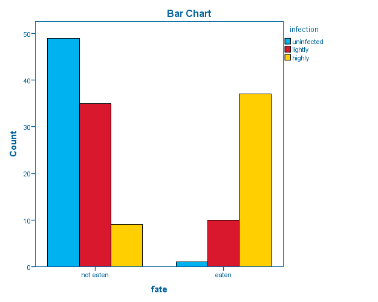

Log  
Log - Log - August 15, 2018

DATASET ACTIVATE DataSet6.  
GET  
FILE='C:\Users\Heather\OneDrive - Brock University\Masters\TA\BIOL3P96\2019\Lab 5\fry.sav'.  
DATASET NAME DataSet8 WINDOW=FRONT.  
CROSSTABS  
/TABLES=survival BY frySource  
/FORMAT=AVALUE TABLES  
/STATISTICS=CHISQ  
/CELLS=COUNT EXPECTED  
/COUNT ROUND CELL  
/BARCHART.

Crosstabs  
Crosstabs - Active Dataset - August 15, 2018

[DataSet8] C:\Users\Heather\OneDrive - Brock University\Masters\TA\BIOL3P96\2019\Lab 5\fry.sav

Crosstabs  
Crosstabs - Case Processing Summary - August 15, 2018

Case Processing SummaryCase Processing Summary, table, 3 levels of column headers and 1 levels of row headers, table with 7 columns and 5 rows

|  | Cases |  |  |  |  |  |
| --- | --- | --- | --- | --- | --- | --- |
|  | Valid |  | Missing |  | Total |  |
|  | N | Percent | N | Percent | N | Percent |
| survival * frySource | 8000 | 100.0% | 0 | 0.0% | 8000 | 100.0% |

Crosstabs  
Crosstabs - survival * frySource Crosstabulation - August 15, 2018

survival * frySource Crosstabulationsurvival * frySource Crosstabulation, table, 2 levels of column headers and 3 levels of row headers, table with 6 columns and 9 rows

|  |  |  | frySource |  | Total |  |
| --- | --- | --- | --- | --- | --- | --- |
|  |  |  | wild | hatchery |  |  |
| survival | survived | Count | 51 | 27 |  | 78 |
|  |  | Expected Count | 39.0 | 39.0 | 78.0 |  |
|  | perished | Count | 3949 | 3973 | 7922 |  |
|  |  | Expected Count | 3961.0 | 3961.0 | 7922.0 |  |
| Total |  | Count | 4000 | 4000 | 8000 |  |
|  |  | Expected Count | 4000.0 | 4000.0 | 8000.0 |  |

Crosstabs  
Crosstabs - Chi-Square Tests - August 15, 2018

Chi-Square TestsChi-Square Tests, table, 1 levels of column headers and 1 levels of row headers, table with 6 columns and 9 rows

|  | Value | df | Asymptotic Significance (2-sided) | Exact Sig. (2-sided) | Exact Sig. (1-sided) |
| --- | --- | --- | --- | --- | --- |
| Pearson Chi-Square | 7.457<sup>a</sup> | 1 | .006 |  |  |
| Continuity Correction<sup>b</sup> | 6.849 | 1 | .009 |  |  |
| Likelihood Ratio | 7.578 | 1 | .006 |  |  |
| Fisher's Exact Test |  |  |  | .008 | .004 |
| N of Valid Cases | 8000 |  |  |  |  |

a. 0 cells (0.0%) have expected count less than 5. The minimum expected count is 39.00.  
b. Computed only for a 2x2 table

Crosstabs  
Crosstabs - Bar Chart - August 15, 2018

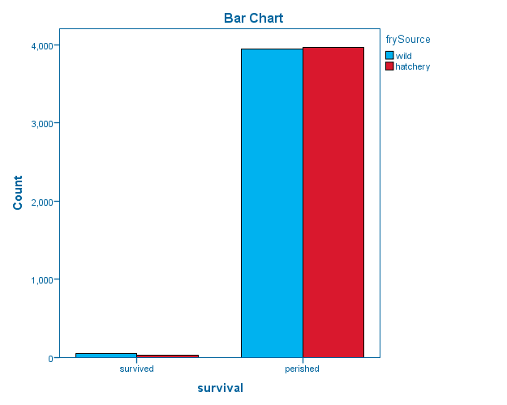

Log  
Log - Log - August 15, 2018

GET  
FILE='C:\Users\Heather\OneDrive - Brock University\Masters\TA\BIOL3P96\2019\Lab 5\delivery.sav'.  
>Warning # 5281. Command name: GET FILE  
>SPSS Statistics is running in Unicode encoding mode. This file is encoded in  
>a locale-specific (code page) encoding. The defined width of any string  
>variables are automatically tripled in order to avoid possible data loss. You  
>can use ALTER TYPE to set the width of string variables to the width of the  
>longest observed value for each string variable.  
ALTER TYPE ALL(A=AMIN).

Alter Type  
Alter Type - Active Dataset - August 15, 2018

C:\Users\Heather\OneDrive - Brock University\Masters\TA\BIOL3P96\2019\Lab 5\delivery.sav

Alter Type  
Alter Type - Altered Types - August 15, 2018

Altered TypesAltered Types, table, 0 levels of column headers and 2 levels of row headers, table with 3 columns and 3 rows

| Delivery | A27 | AMIN |
| --- | --- | --- |
| Depression | A39 | AMIN |

Log  
Log - Log - August 15, 2018

DATASET NAME DataSet9 WINDOW=FRONT.  
CROSSTABS  
/TABLES=Delivery BY Depression  
/FORMAT=AVALUE TABLES  
/STATISTICS=RISK  
/CELLS=COUNT ROW  
/COUNT ROUND CELL.

Crosstabs  
Crosstabs - Active Dataset - August 15, 2018

[DataSet9] C:\Users\Heather\OneDrive - Brock University\Masters\TA\BIOL3P96\2019\Lab 5\delivery.sav

Crosstabs  
Crosstabs - Case Processing Summary - August 15, 2018

Case Processing SummaryCase Processing Summary, table, 3 levels of column headers and 1 levels of row headers, table with 7 columns and 5 rows

|  | Cases |  |  |  |  |  |
| --- | --- | --- | --- | --- | --- | --- |
|  | Valid |  | Missing |  | Total |  |
|  | N | Percent | N | Percent | N | Percent |
| Delivery * Depression | 10934 | 100.0% | 0 | 0.0% | 10934 | 100.0% |

Crosstabs  
Crosstabs - Delivery * Depression Crosstabulation - August 15, 2018

Delivery * Depression CrosstabulationDelivery * Depression Crosstabulation, table, 2 levels of column headers and 3 levels of row headers, table with 6 columns and 9 rows

|  |  |  | Depression |  | Total |  |
| --- | --- | --- | --- | --- | --- | --- |
|  |  |  | Depression | No depression |  |  |
| Delivery | C-section | Count | 48 | 341 |  | 389 |
|  |  | % within Delivery | 12.3% | 87.7% | 100.0% |  |
|  | vaginal | Count | 1025 | 9520 | 10545 |  |
|  |  | % within Delivery | 9.7% | 90.3% | 100.0% |  |
| Total |  | Count | 1073 | 9861 | 10934 |  |
|  |  | % within Delivery | 9.8% | 90.2% | 100.0% |  |

Crosstabs  
Crosstabs - Risk Estimate - August 15, 2018

Risk EstimateRisk Estimate, table, 2 levels of column headers and 1 levels of row headers, table with 4 columns and 7 rows

|  | Value | 95% Confidence Interval |  |
| --- | --- | --- | --- |
|  |  | Lower | Upper |
| Odds Ratio for Delivery (C-section / vaginal) | 1.307 | .960 | 1.781 |
| For cohort Depression = Depression | 1.269 | .968 | 1.665 |
| For cohort Depression = No depression | .971 | .935 | 1.008 |
| N of Valid Cases | 10934 |  |  |

Log  
Log - Log - August 15, 2018

CROSSTABS  
/TABLES=Delivery BY Depression  
/FORMAT=AVALUE TABLES  
/STATISTICS=CHISQ RISK  
/CELLS=COUNT EXPECTED  
/COUNT ROUND CELL  
/BARCHART.

Crosstabs  
Crosstabs - Case Processing Summary - August 15, 2018

Case Processing SummaryCase Processing Summary, table, 3 levels of column headers and 1 levels of row headers, table with 7 columns and 5 rows

|  | Cases |  |  |  |  |  |
| --- | --- | --- | --- | --- | --- | --- |
|  | Valid |  | Missing |  | Total |  |
|  | N | Percent | N | Percent | N | Percent |
| Delivery * Depression | 10934 | 100.0% | 0 | 0.0% | 10934 | 100.0% |

Crosstabs  
Crosstabs - Delivery * Depression Crosstabulation - August 15, 2018

Delivery * Depression CrosstabulationDelivery * Depression Crosstabulation, table, 2 levels of column headers and 3 levels of row headers, table with 6 columns and 9 rows

|  |  |  | Depression |  | Total |  |
| --- | --- | --- | --- | --- | --- | --- |
|  |  |  | Depression | No depression |  |  |
| Delivery | C-section | Count | 48 | 341 |  | 389 |
|  |  | Expected Count | 38.2 | 350.8 | 389.0 |  |
|  | vaginal | Count | 1025 | 9520 | 10545 |  |
|  |  | Expected Count | 1034.8 | 9510.2 | 10545.0 |  |
| Total |  | Count | 1073 | 9861 | 10934 |  |
|  |  | Expected Count | 1073.0 | 9861.0 | 10934.0 |  |

Crosstabs  
Crosstabs - Chi-Square Tests - August 15, 2018

Chi-Square TestsChi-Square Tests, table, 1 levels of column headers and 1 levels of row headers, table with 6 columns and 9 rows

|  | Value | df | Asymptotic Significance (2-sided) | Exact Sig. (2-sided) | Exact Sig. (1-sided) |
| --- | --- | --- | --- | --- | --- |
| Pearson Chi-Square | 2.908<sup>a</sup> | 1 | .088 |  |  |
| Continuity Correction<sup>b</sup> | 2.619 | 1 | .106 |  |  |
| Likelihood Ratio | 2.718 | 1 | .099 |  |  |
| Fisher's Exact Test |  |  |  | .095 | .053 |
| N of Valid Cases | 10934 |  |  |  |  |

a. 0 cells (0.0%) have expected count less than 5. The minimum expected count is 38.17.  
b. Computed only for a 2x2 table

Crosstabs  
Crosstabs - Risk Estimate - August 15, 2018

Risk EstimateRisk Estimate, table, 2 levels of column headers and 1 levels of row headers, table with 4 columns and 7 rows

|  | Value | 95% Confidence Interval |  |
| --- | --- | --- | --- |
|  |  | Lower | Upper |
| Odds Ratio for Delivery (C-section / vaginal) | 1.307 | .960 | 1.781 |
| For cohort Depression = Depression | 1.269 | .968 | 1.665 |
| For cohort Depression = No depression | .971 | .935 | 1.008 |
| N of Valid Cases | 10934 |  |  |

Crosstabs  
Crosstabs - Bar Chart - August 15, 2018

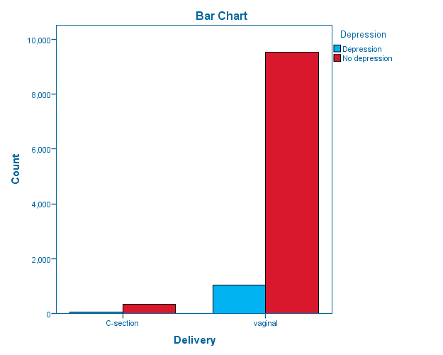

Log  
Log - Log - August 15, 2018

GET  
FILE='C:\Users\Heather\OneDrive - Brock University\Masters\TA\BIOL3P96\2019\Lab 5\heart failure.sav'.  
>Warning # 5281. Command name: GET FILE  
>SPSS Statistics is running in Unicode encoding mode. This file is encoded in  
>a locale-specific (code page) encoding. The defined width of any string  
>variables are automatically tripled in order to avoid possible data loss. You  
>can use ALTER TYPE to set the width of string variables to the width of the  
>longest observed value for each string variable.  
DATASET NAME DataSet10 WINDOW=FRONT.  
NPAR TESTS  
/CHISQUARE=NumberAdmitted  
/EXPECTED=EQUAL  
/MISSING ANALYSIS.

NPar Tests  
NPar Tests - Active Dataset - August 15, 2018

[DataSet10] C:\Users\Heather\OneDrive - Brock University\Masters\TA\BIOL3P96\2019\Lab 5\heart failure.sav

Frequencies  
Frequencies - NumberAdmitted - August 15, 2018

NumberAdmittedNumberAdmitted, table, 1 levels of column headers and 1 levels of row headers, table with 4 columns and 10 rows

|  | Observed N | Expected N | Residual |
| --- | --- | --- | --- |
| 78.00 | 78 | 104.1 | -26.1 |
| 83.00 | 83 | 104.1 | -21.1 |
| 105.00 | 105 | 104.1 | .9 |
| 108.00 | 108 | 104.1 | 3.9 |
| 109.00 | 109 | 104.1 | 4.9 |
| 117.00 | 117 | 104.1 | 12.9 |
| 129.00 | 129 | 104.1 | 24.9 |
| Total | 729 |  |  |

Chi-Square Test  
Chi-Square Test - Test Statistics - August 15, 2018

Test StatisticsTest Statistics, table, 1 levels of column headers and 1 levels of row headers, table with 2 columns and 6 rows

|  | NumberAdmitted |
| --- | --- |
| Chi-Square | 18.752<sup>a</sup> |
| df | 6 |
| Asymp. Sig. | .005 |

a. 0 cells (0.0%) have expected frequencies less than 5. The minimum expected cell frequency is 104.1.

Log  
Log - Log - August 15, 2018

GET  
FILE='C:\Users\Heather\OneDrive - Brock University\Masters\TA\BIOL3P96\2019\Lab 5\raining cats.sav'.  
>Warning # 5281. Command name: GET FILE  
>SPSS Statistics is running in Unicode encoding mode. This file is encoded in  
>a locale-specific (code page) encoding. The defined width of any string  
>variables are automatically tripled in order to avoid possible data loss. You  
>can use ALTER TYPE to set the width of string variables to the width of the  
>longest observed value for each string variable.  
DATASET NAME DataSet11 WINDOW=FRONT.  
NPAR TESTS  
/CHISQUARE=month  
/EXPECTED=EQUAL  
/MISSING ANALYSIS.

NPar Tests  
NPar Tests - Active Dataset - August 15, 2018

[DataSet11] C:\Users\Heather\OneDrive - Brock University\Masters\TA\BIOL3P96\2019\Lab 5\raining cats.sav

Frequencies  
Frequencies - month - August 15, 2018

monthmonth, table, 1 levels of column headers and 1 levels of row headers, table with 4 columns and 15 rows

|  | Observed N | Expected N | Residual |
| --- | --- | --- | --- |
| January | 4 | 9.9 | -5.9 |
| February | 6 | 9.9 | -3.9 |
| March | 8 | 9.9 | -1.9 |
| April | 10 | 9.9 | .1 |
| May | 9 | 9.9 | -.9 |
| June | 14 | 9.9 | 4.1 |
| July | 19 | 9.9 | 9.1 |
| August | 13 | 9.9 | 3.1 |
| September | 12 | 9.9 | 2.1 |
| October | 12 | 9.9 | 2.1 |
| November | 7 | 9.9 | -2.9 |
| December | 5 | 9.9 | -4.9 |
| Total | 119 |  |  |

Chi-Square Test  
Chi-Square Test - Test Statistics - August 15, 2018

Test StatisticsTest Statistics, table, 1 levels of column headers and 1 levels of row headers, table with 2 columns and 6 rows

|  | month |
| --- | --- |
| Chi-Square | 20.664<sup>a</sup> |
| df | 11 |
| Asymp. Sig. | .037 |

a. 0 cells (0.0%) have expected frequencies less than 5. The minimum expected cell frequency is 9.9.

Log  
Log - Log - August 15, 2018

GET  
FILE='C:\Users\Heather\OneDrive - Brock University\Masters\TA\BIOL3P96\2019\Lab 5\CCSVI.sav'.  
>Warning # 5281. Command name: GET FILE  
>SPSS Statistics is running in Unicode encoding mode. This file is encoded in  
>a locale-specific (code page) encoding. The defined width of any string  
>variables are automatically tripled in order to avoid possible data loss. You  
>can use ALTER TYPE to set the width of string variables to the width of the  
>longest observed value for each string variable.  
DATASET NAME DataSet12 WINDOW=FRONT.  
CROSSTABS  
/TABLES=CCSVI BY MS  
/FORMAT=AVALUE TABLES  
/STATISTICS=CHISQ  
/CELLS=COUNT  
/COUNT ROUND CELL  
/BARCHART.

Crosstabs  
Crosstabs - Active Dataset - August 15, 2018

[DataSet12] C:\Users\Heather\OneDrive - Brock University\Masters\TA\BIOL3P96\2019\Lab 5\CCSVI.sav

Crosstabs  
Crosstabs - Case Processing Summary - August 15, 2018

Case Processing SummaryCase Processing Summary, table, 3 levels of column headers and 1 levels of row headers, table with 7 columns and 5 rows

|  | Cases |  |  |  |  |  |
| --- | --- | --- | --- | --- | --- | --- |
|  | Valid |  | Missing |  | Total |  |
|  | N | Percent | N | Percent | N | Percent |
| CCSVI * MS | 65 | 100.0% | 0 | 0.0% | 65 | 100.0% |

Crosstabs  
Crosstabs - CCSVI * MS Crosstabulation - August 15, 2018

CCSVI * MS CrosstabulationCCSVI * MS Crosstabulation, table, Count, 1 layers, 2 levels of column headers and 2 levels of row headers, table with 5 columns and 7 rows

| Count Count |  |  |  |  |  |
| --- | --- | --- | --- | --- | --- |
|  |  | MS |  | Total |  |
|  |  | No MS | MS |  |  |
| CCSVI | No CCSVI | 12 | 14 |  | 26 |
|  | CCSVI | 14 | 25 | 39 |  |
| Total |  | 26 | 39 | 65 |  |

Crosstabs  
Crosstabs - Chi-Square Tests - August 15, 2018

Chi-Square TestsChi-Square Tests, table, 1 levels of column headers and 1 levels of row headers, table with 6 columns and 10 rows

|  | Value | df | Asymptotic Significance (2-sided) | Exact Sig. (2-sided) | Exact Sig. (1-sided) |
| --- | --- | --- | --- | --- | --- |
| Pearson Chi-Square | .684<sup>a</sup> | 1 | .408 |  |  |
| Continuity Correction<sup>b</sup> | .323 | 1 | .570 |  |  |
| Likelihood Ratio | .681 | 1 | .409 |  |  |
| Fisher's Exact Test |  |  |  | .447 | .284 |
| Linear-by-Linear Association | .673 | 1 | .412 |  |  |
| N of Valid Cases | 65 |  |  |  |  |

a. 0 cells (0.0%) have expected count less than 5. The minimum expected count is 10.40.  
b. Computed only for a 2x2 table

Crosstabs  
Crosstabs - Bar Chart - August 15, 2018

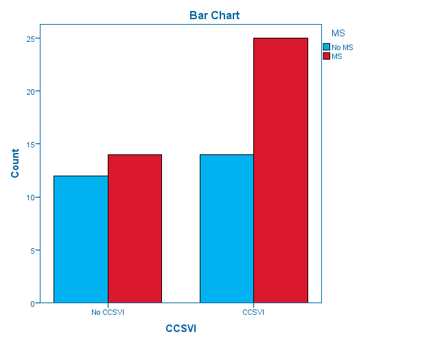

Log  
Log - Log - August 15, 2018

GET  
FILE='C:\Users\Heather\OneDrive - Brock University\Masters\TA\BIOL3P96\2019\Lab 5\smoking fingers.sav'.  
DATASET NAME DataSet13 WINDOW=FRONT.  
CROSSTABS  
/TABLES=maternalSmoking BY fingerType  
/FORMAT=AVALUE TABLES  
/STATISTICS=RISK  
/CELLS=COUNT ROW  
/COUNT ROUND CELL.

Crosstabs  
Crosstabs - Active Dataset - August 15, 2018

[DataSet13] C:\Users\Heather\OneDrive - Brock University\Masters\TA\BIOL3P96\2019\Lab 5\smoking fingers.sav

Crosstabs  
Crosstabs - Case Processing Summary - August 15, 2018

Case Processing SummaryCase Processing Summary, table, 3 levels of column headers and 1 levels of row headers, table with 7 columns and 5 rows

|  | Cases |  |  |  |  |  |
| --- | --- | --- | --- | --- | --- | --- |
|  | Valid |  | Missing |  | Total |  |
|  | N | Percent | N | Percent | N | Percent |
| maternalSmoking * fingerType | 15513 | 100.0% | 0 | 0.0% | 15513 | 100.0% |

Crosstabs  
Crosstabs - maternalSmoking * fingerType Crosstabulation - August 15, 2018

maternalSmoking * fingerType CrosstabulationmaternalSmoking * fingerType Crosstabulation, table, 2 levels of column headers and 3 levels of row headers, table with 6 columns and 9 rows

|  |  |  | fingerType |  | Total |  |
| --- | --- | --- | --- | --- | --- | --- |
|  |  |  | defect | normal |  |  |
| maternalSmoking | smoker | Count | 805 | 1280 |  | 2085 |
|  |  | % within maternalSmoking | 38.6% | 61.4% | 100.0% |  |
|  | non-smoker | Count | 4366 | 9062 | 13428 |  |
|  |  | % within maternalSmoking | 32.5% | 67.5% | 100.0% |  |
| Total |  | Count | 5171 | 10342 | 15513 |  |
|  |  | % within maternalSmoking | 33.3% | 66.7% | 100.0% |  |

Crosstabs  
Crosstabs - Risk Estimate - August 15, 2018

Risk EstimateRisk Estimate, table, 2 levels of column headers and 1 levels of row headers, table with 4 columns and 7 rows

|  | Value | 95% Confidence Interval |  |
| --- | --- | --- | --- |
|  |  | Lower | Upper |
| Odds Ratio for maternalSmoking (smoker / non-smoker) | 1.305 | 1.187 | 1.436 |
| For cohort fingerType = defect | 1.187 | 1.119 | 1.260 |
| For cohort fingerType = normal | .910 | .878 | .943 |
| N of Valid Cases | 15513 |  |  |

Log  
Log - Log - August 15, 2018

Crosstabs  
Crosstabs - Case Processing Summary - August 15, 2018

Case Processing SummaryCase Processing Summary, table, 3 levels of column headers and 1 levels of row headers, table with 7 columns and 5 rows

|  | Cases |  |  |  |  |  |
| --- | --- | --- | --- | --- | --- | --- |
|  | Valid |  | Missing |  | Total |  |
|  | N | Percent | N | Percent | N | Percent |
| maternalSmoking * fingerType | 15513 | 100.0% | 0 | 0.0% | 15513 | 100.0% |

Crosstabs  
Crosstabs - maternalSmoking * fingerType Crosstabulation - August 15, 2018

maternalSmoking * fingerType CrosstabulationmaternalSmoking * fingerType Crosstabulation, table, 2 levels of column headers and 3 levels of row headers, table with 6 columns and 9 rows

|  |  |  | fingerType |  | Total |  |
| --- | --- | --- | --- | --- | --- | --- |
|  |  |  | defect | normal |  |  |
| maternalSmoking | smoker | Count | 805 | 1280 |  | 2085 |
|  |  | Expected Count | 695.0 | 1390.0 | 2085.0 |  |
|  | non-smoker | Count | 4366 | 9062 | 13428 |  |
|  |  | Expected Count | 4476.0 | 8952.0 | 13428.0 |  |
| Total |  | Count | 5171 | 10342 | 15513 |  |
|  |  | Expected Count | 5171.0 | 10342.0 | 15513.0 |  |

Crosstabs  
Crosstabs - Chi-Square Tests - August 15, 2018

Chi-Square TestsChi-Square Tests, table, 1 levels of column headers and 1 levels of row headers, table with 6 columns and 10 rows

|  | Value | df | Asymptotic Significance (2-sided) | Exact Sig. (2-sided) | Exact Sig. (1-sided) |
| --- | --- | --- | --- | --- | --- |
| Pearson Chi-Square | 30.170<sup>a</sup> | 1 | .000 |  |  |
| Continuity Correction<sup>b</sup> | 29.896 | 1 | .000 |  |  |
| Likelihood Ratio | 29.574 | 1 | .000 |  |  |
| Fisher's Exact Test |  |  |  | .000 | .000 |
| Linear-by-Linear Association | 30.168 | 1 | .000 |  |  |
| N of Valid Cases | 15513 |  |  |  |  |

a. 0 cells (0.0%) have expected count less than 5. The minimum expected count is 695.00.  
b. Computed only for a 2x2 table

X

ABOUT

Created Using: IBM SPSS Statistics 23

Creation Date: Aug 15, 2018

Document Version: Original

Saved Date: Aug 15, 2018

Navigation Controls

Next & Previous - Display the next or previous table or chart in the Web Report

Help - Opens Help

Toolbar Buttons

[output not shown]

Connecting to a Server

Editing Tables

[output not shown]

Editing Charts

[output not shown]

Save

Server Connection

X  
Saved Server Connections

Status

Add a chart

Pivot and Sort

Chart Size

[output not shown]

Background

Line and Borders

Text Format

Number Format

[output not shown]

Axis Options

[output not shown]